# R Notebook

####################LOOK FOR SUBCLUSTERS IN BEC, THE DONORS AND CORRELATION #####################

```r
## run it later to load all
#bec_obj = readRDS("data/process/temp/bec_obj.RDS")
```

#for the path

#ALL PACKAGES YOU NEED

```r
##packages
library(pacman)
p_load(Seurat,SeuratData,Matrix,dplyr,DropletUtils,presto,gprofiler2,ggplot2,patchwork,gplots,cowplot,gprofiler2,openxlsx, plyr,scDblFinder,BiocParallel)
```

#1LOAD THE DATA

```r
##load the data: from the initial code data_3.rmd

bec_obj = readRDS("data/process/temp/bec_subset.rds")
table(bec_obj$celltype)
```

```
  BEC
21788
```

#2-NORM,FVF,SCALE AND RPCA

```r
###normalize, scale, runpca,find varfeature####

bec_obj = NormalizeData(bec_obj)
bec_obj = FindVariableFeatures(bec_obj)
bec_obj = ScaleData(bec_obj, vars.to.regress = c("nCount_RNA", "percent.mt"))
bec_obj = RunPCA(bec_obj)
```

#3-CHECK THE TRESHOLD FOR THE PCA AND THE RESOLUTION BEFORE FINDING THE CLUSTERS AFTER INTEGRATION.BASED ON DATA SIZE , WE CAN CHOSE A RANGE OF RESOLUTION

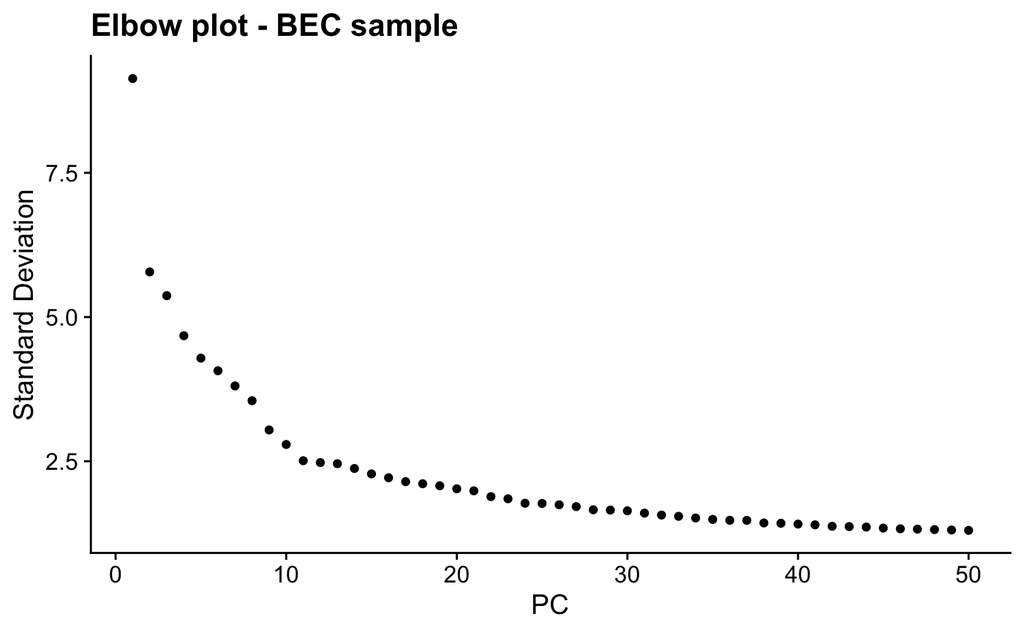

```r
#use ans ELBOWPLOT:shows the variance explained by each principal component (PC).You use it to decide how many PCs to keep
ElbowPlot(bec_obj, ndims = 50, reduction = "pca") +
  ggtitle("Elbow plot - BEC sample")
```

#4-INTEGRATIIN WITH HARMONY

```r
##perform integration: no need to join layers###
library(harmony)
bec_obj =RunHarmony(
  bec_obj,
  group.by.vars = "orig.ident",
  orig.reduction = "pca",
  dims.use = 1:30
)
Reductions(bec_obj) # to check harmony: run succesfully
```

```
[1] "pca"               "umap.unintegrated" "harmony"           "umap.harmony"
```

```r
#visualization
bec_obj = RunUMAP(bec_obj, reduction = "harmony", dims= 1:30, reduction.name = "umap.harmony")
```

```
Using method 'umap'
```

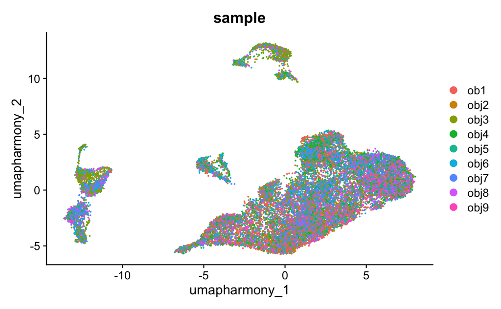

```r
p1=DimPlot(
  bec_obj,
  reduction = "umap.harmony",
  group.by = c("sample"),
 label.size = 2, shuffle = T
)
p1
```

#5-PERFORM DIFFERENT RESOLUTION:

```r
#1 Build the nearest-neighbor graph (required before clustering)
bec_obj <- FindNeighbors(bec_obj, dims = 1:30, reduction = "harmony")

#2 Create clusters at resolutions from 0.3 to 1.0
for (res in seq(0.1,1, by = 0.1)) {
  bec_obj <- FindClusters(bec_obj, resolution = res)
}

#3 Get all clustering resolution columns from metadata
res_cols <- grep("RNA_snn_res", colnames(bec_obj@meta.data), value = TRUE)


#4 Plot each resolution separately
for (res in res_cols) {
  p <- DimPlot(bec_obj, group.by = res, label = TRUE, reduction =  "umap.harmony") +
       ggtitle(paste("Resolution:", res))
  print(p)
}

#5 (Optional) Combine all plots into one grid for comparison
library(patchwork)

plots <- lapply(res_cols, function(res) {
  DimPlot(bec_obj, group.by = res, label = TRUE, reduction = "umap.harmony") +
    ggtitle(paste("Resolution:", res))
})

wrap_plots(plots)
```

[output not shown]

#5-1 CLUSTERS with the resolution choosen

```r
#### clusters after integration
bec_obj = FindNeighbors(bec_obj, reduction="harmony", dims = 1:30)
bec_obj = FindClusters(bec_obj, resolution =0.5, cluster.name = "harmony_clusters")
```

#5-2 PLOTS

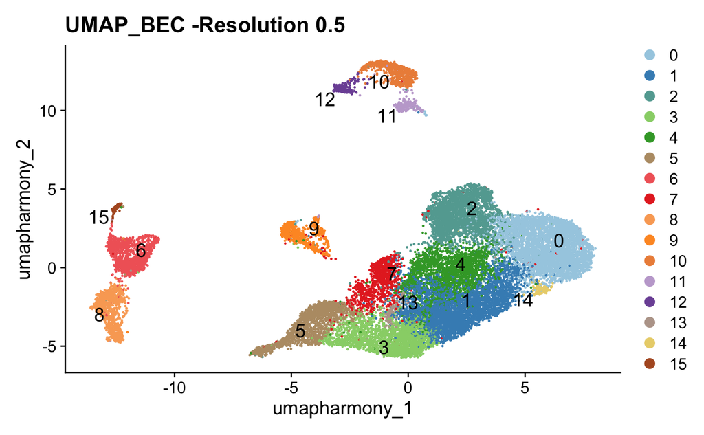

```r
##plots with the clusters

library(RColorBrewer)

# Number of clusters
n_clusters <- length(levels(Idents(bec_obj)))

# Create enough distinct colors
if(n_clusters <= 12){
  my_colors <- brewer.pal(n_clusters, "Paired")
} else {
  # For more than 12 clusters, interpolate a larger palette
  my_colors <- colorRampPalette(brewer.pal(12, "Paired"))(n_clusters)
}

# Set identities if not already
Idents(bec_obj) <- "seurat_clusters"  # replace with your cluster column

# Plot
p = DimPlot(
  bec_obj,
  reduction = "umap.harmony",
  label = T,
  label.size = 5,
  repel = TRUE,
  cols = my_colors
) + ggtitle("UMAP_BEC -Resolution 0.5")
p
#SAVE
ggsave(filename = "output/temp/umap_bec_resolution.png", plot= p, width = 10, height = 8)
```

#6- FIND ALL MARKERS IN ALL CLUSTERS

```r
##find all markers###########################
#first
all_markers_bec = FindAllMarkers(
  bec_obj,
  only.pos = TRUE,     # only genes upregulated in each cluster
  min.pct = 0.25,      # minimum % of cells expressing the gene
  logfc.threshold = 0.25
)
# 2️⃣ Keep only significant markers
all_markers_bec = all_markers_bec %>%
  filter(p_val_adj < 0.05, abs(avg_log2FC) > 0.25)


#3 save (important)
library(openxlsx)
write.xlsx(
  all_markers_bec,
  file = "output/temp/all_markers_bec.xlsx"
)

View(all_markers_bec)
```

#6-1 WE CHECK IF THE CLUSTER EXPRESS THE KEYS MARKERS WE SHOULD HAVE IN BEC POPULATION

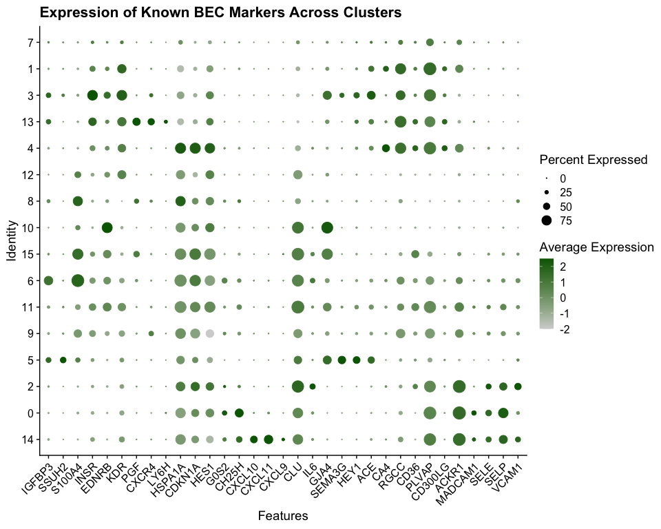

```r
#
bec_markers <- c("IGFBP3", "SSUH2", "S100A4", "INSR", "EDNRB", "KDR", "PGF", "CXCR4", "LY6H", "HSPA1A", "CDKN1A", "HES1", "G0S2","CH25H", "CXCL10", "CXCL11", "CXCL9", "CLU", "IL6","GJA4", "SEMA3G", "HEY1", "ACE",  "CA4", "RGCC", "CD36", "PLVAP", "CD300LG", "ACKR1", "MADCAM1", "SELE", "SELP", "VCAM1")
p=DotPlot(bec_obj, features = bec_markers, cols = c("lightgrey", "darkgreen"), cluster.idents = T,
          group.by = "harmony_clusters") +
  RotatedAxis() + ggtitle("Expression of Known BEC Markers Across Clusters")
p
```

#All THE CLUSTERS PRESENT BEC MARKERS, SO ,NO NEED TO REMOVE ANY CLUSTER, WE MOVE FORWARD

#7-THE NUMBER OF CELLS PER DONORS

```r
#change the colname
bec_obj$Donors = bec_obj$orig.ident

#create the metadata
meta= bec_obj@meta.data[, c("harmony_clusters", "Donors")]
table(meta$Donors)
```

```
 MN1  MN2  MN3  MN4  MN5  MN6  MN7  MN8  MN9
2191 1656 2701 2715 1968 2485 3550 2473 2049
```

```r
# Count cells per donor
cell_counts_per_donor <- as.data.frame(table(meta$Donors))
colnames(cell_counts_per_donor) <- c("Donor", "CellCount")
```

#7-1 PLOT IT

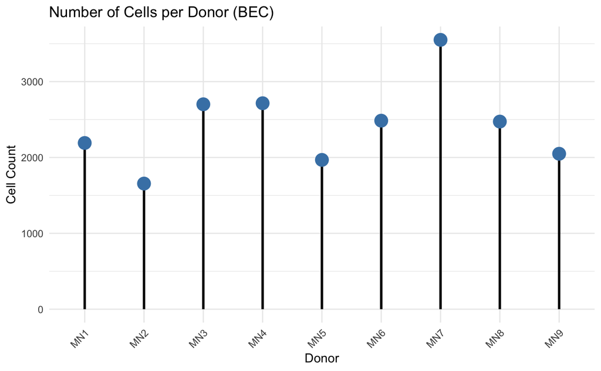

```r
# Count cells per donor
cell_counts_per_donor <- as.data.frame(table(meta$Donors))
colnames(cell_counts_per_donor) <- c("Donor", "CellCount")

p <- ggplot(cell_counts_per_donor, aes(x = Donor, y = CellCount)) +
  geom_segment(aes(x = Donor, xend = Donor, y = 0, yend = CellCount), size = 1) +
  geom_point(size = 5, color = "steelblue") +
  theme_minimal() +
  labs(
    title = "Number of Cells per Donor (BEC)",
    x = "Donor",
    y = "Cell Count"
  ) +
  theme(
    axis.text.x = element_text(angle = 45, hjust = 1)
  )
p

#save
ggsave(filename = "output/temp/Numb_BEC_cell_per_Donor.png", plot = p, height = 8, width = 10)
```

#8-THE PROPORTION OF DONORS IN EACH CLUSTERS

```r
library(dplyr)
library(ggplot2)
library(scales)


# Make sure dplyr functions are used explicitly
meta = bec_obj@meta.data

#the  percentage
donors_counts = meta %>%
  as_tibble() %>%
  dplyr::group_by(harmony_clusters,Donors) %>% #count cells each donor use in each cluster
  dplyr::summarise( n= dplyr::n(),.groups = "drop") %>% #numb of cells
  dplyr::group_by(harmony_clusters) %>%
  dplyr::mutate(proportion = n /sum(n))  #fraction of cells per donor
```

#8-1 PLOT

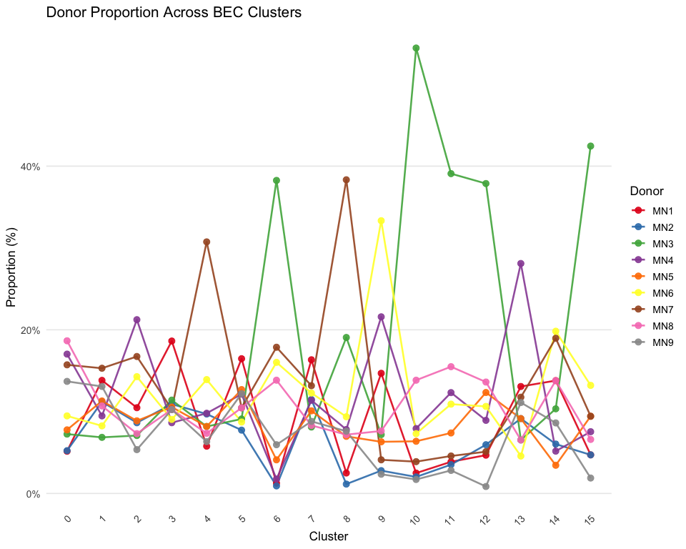

```r
#####
p <- ggplot(donors_counts, aes(
  x = harmony_clusters,
  y = proportion,
  group = Donors,
  color = Donors
)) +
  geom_line(linewidth = 0.9, alpha = 0.9) +
  geom_point(size = 2.8, alpha = 0.9) +
  scale_y_continuous(labels = scales::percent) +
  # Use a colorblind-friendly palette with distinct colors
  scale_color_brewer(palette = "Set1", name = "Donor") +
  theme_minimal(base_size = 13) +
  labs(
    title = "Donor Proportion Across BEC Clusters",
    x = "Cluster",
    y = "Proportion (%)"
  ) +
  theme(
    panel.grid.minor = element_blank(),
    panel.grid.major.x = element_blank(),
    axis.text.x = element_text(angle = 45, hjust = 1),
    legend.position = "right"
  )
p
```

```r
#save the plot
ggsave(filename = "output/temp/Proportion_donor_per_BEC_cluster.png", plot = p, height = 8, width = 10)
```

#9-1 the AverageExpression with markers genes(within clusters)

```r
#1-EXTRACT THE MARKER GENES#####
library(openxlsx)
colnames(all_markers_bec)

#select col#if we have to save it but not necessary
marker = all_markers_bec[, c("gene", "cluster", "avg_log2FC", "p_val_adj")]
#remove duplicate
marker_genes = unique(marker)

#2-GET UNIQUE MARKER GENES
marker_genes = unique(all_markers_bec$gene)

#3 filter MG
#all genes in rna assay
gene_in_bec = rownames(bec_obj[["RNA"]])

#only genes present in the object
marker_genes_filtered <- marker_genes[marker_genes %in% gene_in_bec]

length(marker_genes_filtered)  # should be > 0

#4 averageEpression per cluster
avr_exp = AverageExpression(
  bec_obj,
  features = marker_genes_filtered,
  assays = "RNA",
  slot = "data"
)

#3 to get the matrix
avr_exp_matrix = avr_exp$RNA
dim(avr_exp_matrix)
```

#9-1PLOT

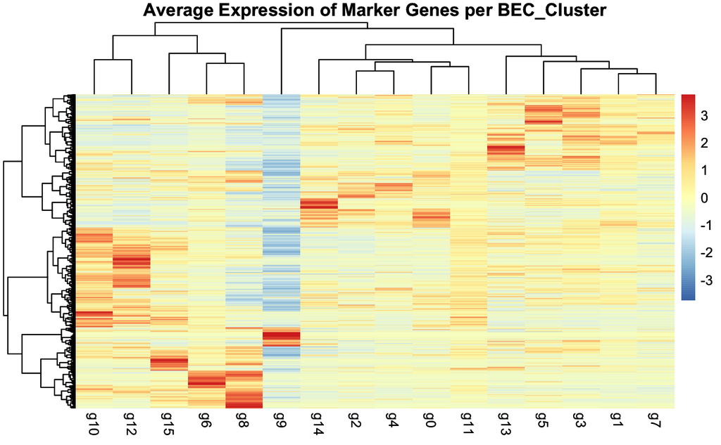

```r
#plot
library(pheatmap)
p=pheatmap(
  avr_exp_matrix,
  scale = "row",
  show_rownames = FALSE,
  clustering_method = "ward.D2",
  main = "Average Expression of Marker Genes per BEC_Cluster"
)
p
```

```r
ggsave(
  filename = "output/temp/avr_Bec.png",
  plot = p,
  width = 10,
  height = 8
)
```

#10 THE CORRELATION

```r
#1-correlation between clusters
#need numeric matrix
avr_exp_matrix = as.matrix(avr_exp$RNA)
#correlation
cluster_cor = cor(avr_exp_matrix,method = "spearman") # or spearman
```

#10-1 PLOT

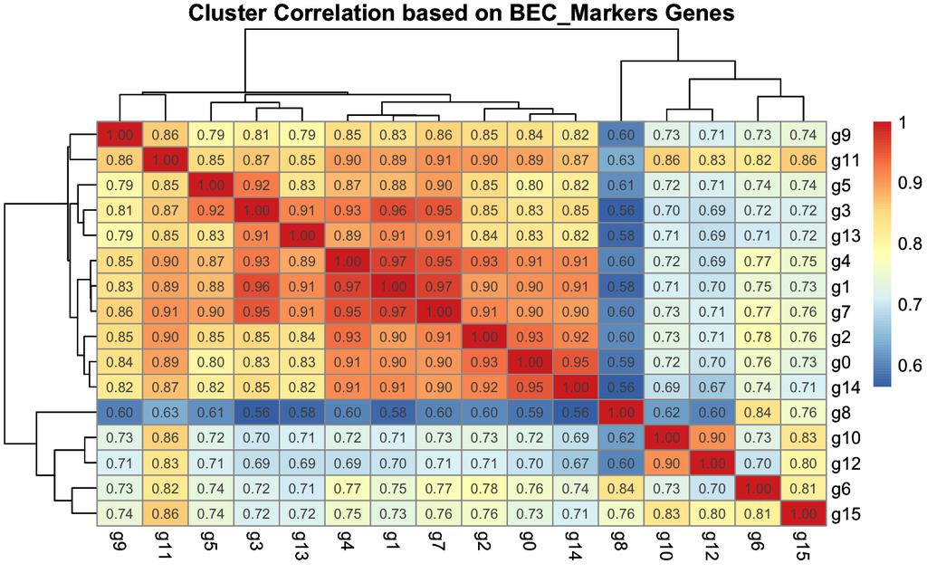

```r
#plots
p=pheatmap(
  cluster_cor,
  cluster_rows = TRUE,
  cluster_cols = TRUE,
  display_numbers = TRUE,
  main = "Cluster Correlation based on BEC_Markers Genes"
)
p
```

```r
#to save


ggsave(file ="output/temp/cor_bec.png", plot = p, width = 10, height = 8, dpi = 300)
```

#11-ANNOTATION:BASED ON THE KEYS MARKERS FROM THE PAPERS AND ALSO THE CORRELATION

```r
#BASED ON THE EXPRESSION OF MARKERS FROM #5 and the CORRELATION LETS ANNOTATE
new_ann = c(
  "0"="Activated-HEV", "1"="Capillary", "2"="Venous", "3"="Arterioles", "4"="Transitional-and-Activated-HEV", "5"="Large-Arteries", "6"="Transitional-and-Activated-HEV", "7"="Capillary", "8"="Transitional-and-Activated-HEV", "9"="Transitional-and-Activated-HEV",
  "10"="Large-Arteries", "11"="Venous", "12"="Transitional-and-Activated-HEV", "13"="tips", "14"="CXCL10-HEV", "15"="Venous"
)

#Save the cell type labels in metadata
bec_obj$new_ann = (mapvalues(
  x = as.character(bec_obj$harmony_clusters),#map numb as string
  from = names(new_ann),
  to = new_ann
))

 #Convert to factor and drop unused levels
bec_obj$new_ann <- factor(bec_obj$new_ann, levels = unique(new_ann))
table(bec_obj$new_ann)
```

```
                 Activated-HEV                      Capillary                         Venous                     Arterioles
                          4052                           4787                           2947                           2244
Transitional-and-Activated-HEV                 Large-Arteries                           tips                     CXCL10-HEV
                          5231                           2258                            153                            116
```

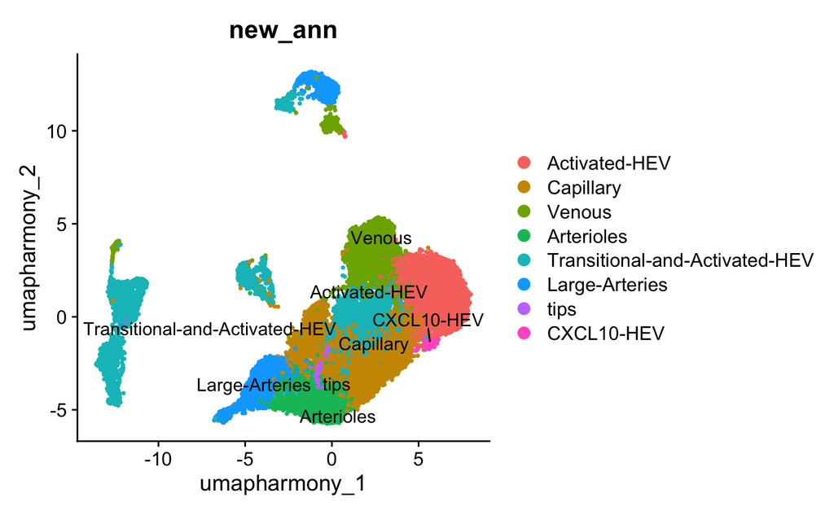

```r
plt = DimPlot(
  bec_obj,
  reduction = "umap.harmony",
  group.by = "new_ann",   # legend will show cell type names
  label = T,            # optional: add labels on UMAP
  repel = TRUE,            # avoid overlapping labels
  pt.size = 0.5
)
plt
```

```r
NA
NA
```

# WE HAVE THREE POPULATIONS OF BEC: CAPILLARY, ARTILLARY AND VENOUS AND EACH OF THEM HAS DIFFERENT SUBPOPULATION. SO WE MAKE PLOT COLORED BASED ON THESE THREE.

#STEP1

```r
library(dplyr)
library(ggplot2)
library(ggrepel)

# Extract UMAP coordinates
umap_coords <- Embeddings(bec_obj, "umap.harmony")  # adjust if your reduction is different
colnames(umap_coords) <- c("UMAP1", "UMAP2")        # make sure column names are standard

# Combine with metadata
plot_df <- bec_obj@meta.data %>%
  cbind(umap_coords)

# Check
head(plot_df)
```

#STEP2

```r
  # Define families
arterial  <- c("Large-Arteries", "Arterioles")
capillary <- c("Capillary" , "Transitional-and-Activated-HEV" , "tips")
venous    <- c("Venous", "Activated-HEV", "CXCL10-HEV")

# Assign major_type
plot_df$major_type <- dplyr::case_when(
  plot_df$new_ann %in% arterial  ~ "Arterial",
  plot_df$new_ann %in% capillary ~ "Capillary",
  plot_df$new_ann %in% venous    ~ "Venous",
  TRUE                            ~ "Other"
)

# Convert to factor with specific order
plot_df$major_type <- factor(plot_df$major_type, levels = c("Arterial", "Capillary", "Venous", "Other"))

# Check counts
table(plot_df$major_type)
```

#STEP3

```r
subtypes <- unique(plot_df$new_ann)

centroids <- data.frame(
  new_ann = subtypes,
  UMAP1 = sapply(subtypes, function(x) median(plot_df$UMAP1[plot_df$new_ann == x], na.rm = TRUE)),
  UMAP2 = sapply(subtypes, function(x) median(plot_df$UMAP2[plot_df$new_ann == x], na.rm = TRUE))
)

# Add major_type to centroids
centroids$major_type <- sapply(centroids$new_ann, function(x) plot_df$major_type[plot_df$new_ann == x][1])
centroids$major_type <- factor(centroids$major_type, levels = c("Arterial","Capillary","Venous","Other"))

# Check
centroids
```

#STEP4

```r
# look for colors
major_colors <- c(
  "Arterial"  = "#D55E00",
  "Capillary" = "#0072B2",
  "Venous"    = "#009E73",
  "Other"     = "grey80"
)
```

#STEP5

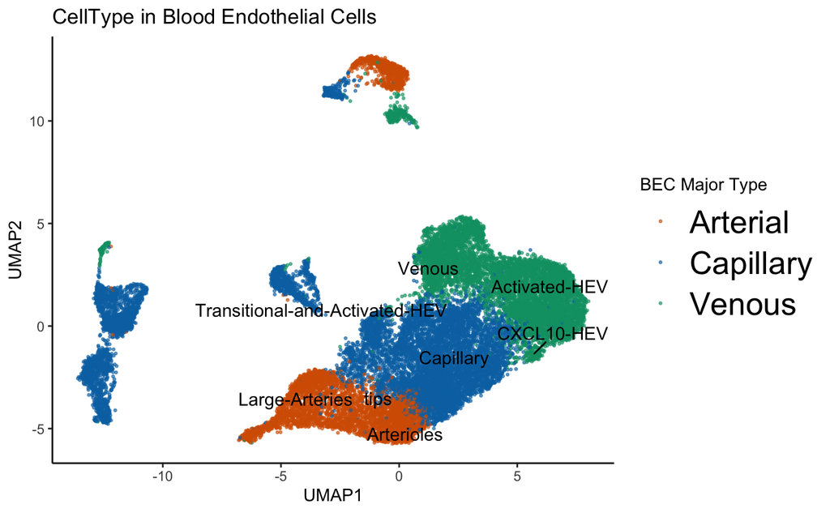

```r
#THE plot
p=ggplot(plot_df, aes(x = UMAP1, y = UMAP2, color = major_type)) +
  geom_point(size = 0.5, alpha = 0.6) +       # plot all cells
  geom_text_repel(
    data = centroids,
    aes(x = UMAP1, y = UMAP2, label = new_ann),
    size = 4,
    color = "black",
    max.overlaps = Inf
  ) +
  labs(color = "BEC Major Type", title = "CellType in Blood Endothelial Cells") +
  theme_classic() +
  scale_color_manual(values = major_colors) + # color by major type
  theme(
    legend.key.size = unit(1.8, "lines"),   # increase the size of the colored boxes
    legend.text = element_text(size = 20)   # increase the text labels
  )


p
#save
ggsave(filename = "output/temp/BecCellType.png", plot= p, width = 10, height = 8)
```

#12 FINALLY WE HAVE THE CLUSTERS NAME , SO WE CAN HAVE THE DIMPLOT .

```r
library(Seurat)
library(ggplot2)

# Define your marker genes
bec_markers = c(
  "IGFBP3", "SSUH2", "S100A4", "INSR", "EDNRB", "KDR", "PGF",
  "CXCR4", "LY6H", "HSPA1A", "CDKN1A", "HES1", "G0S2", "CH25H",
  "CXCL10", "CXCL11", "CXCL9", "CLU", "IL6",
  "GJA4", "SEMA3G", "HEY1", "ACE", "CA4", "RGCC", "CD36",
  "PLVAP", "CD300LG", "ACKR1", "MADCAM1", "SELE", "SELP", "VCAM1"
)

# Make sure 'new_ann' is a factor (so clusters are ordered properly)
# Optional: reorder if you want a specific grouping
bec_obj$new_ann <- factor(bec_obj$new_ann, levels = unique(bec_obj$new_ann))

# For example, ordering manually to group similar clusters together
desired_order = c("Large-Arteries", "Arterioles","Capillary","Transitional-and-Activated-HEV","tips", "Venous",  "CXCL10-HEV","Activated-HEV")
bec_obj$new_ann = factor(bec_obj$new_ann, levels = desired_order)


# Create the dot plot
p <- DotPlot(
  object = bec_obj,
  features = bec_markers,
  cols = c("lightgrey", "darkgreen"),
  group.by = "new_ann"
) +
  RotatedAxis() +
  ggtitle("Expression of Known BEC Markers Across Clusters") +
  theme(
    axis.text.y = element_text(size = 20),  # increase y-axis text
    axis.text.x = element_text(size = 11)   # optional: increase x-axis text
  )
p

#save
ggsave(filename = "output/temp/BecMarker.png", plot= p, width = 12, height = 8)
```

[output not shown]

#feature plot:optional

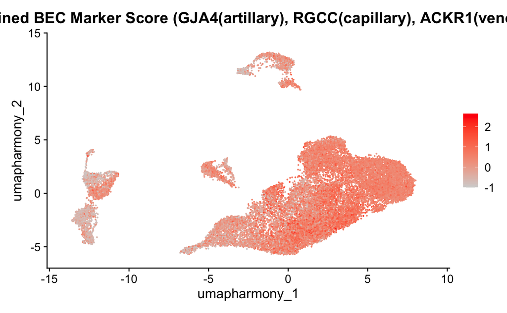

```r
#the markers
bec_markers = c("GJA4","RGCC","ACKR1")

#Combine markers into a “module score” to get ONE clean plot
bec_obj <- AddModuleScore(
  object = bec_obj,
  features = list(bec_markers),
  name = "BECScore"
)
#plot
p=FeaturePlot(
  bec_obj,
  features = "BECScore1",
  reduction = "umap.harmony",
  cols = c("lightgrey", "red")
) +
  ggtitle("Combined BEC Marker Score (GJA4(artillary), RGCC(capillary), ACKR1(venous))")
p
#save
ggsave(filename = "output/temp/BecMarker_feature.png", plot= p, width = 10, height = 8)
```

```r
##save the file and open a new script to remove and keep this to always have the scripts.
saveRDS(bec_obj,file = "data/process/temp/bec_obj.RDS")

## run it later to load all
#bec_obj = readRDS("data/process/temp/bec_obj.RDS")
#recommanded
#bec_obj <- UpdateSeuratObject(bec_obj)
```